# Reproduce analysis for the paper ‘Measuring gig economy in Poland using mobile big data’

Author

Mciej Beręsewicz

# 1 Packages and session info

```r
install.packages(c("tidyverse", "scales", "ggh4x", "ggrepel", "xtable"))
```

```r
library(tidyverse)
library(scales)
library(ggh4x)
library(ggrepel)
library(xtable)
theme_set(theme_bw())
```

# 2 Read the data

Data purchased from Selectivv

- 1 – monthly statistics
- 2 – characteristics
- 3 – place of residence
- 4 - app activity

```r
selectivv <- list()
selectivv[[1]] <- read_csv(file = "data-raw/gig-table1-monthly-counts-stats.csv", show_col_types = F)
selectivv[[2]] <- read_csv(file = "data-raw/gig-table2-halfyear-demo-stats.csv", show_col_types = F)
selectivv[[3]] <- read_csv(file = "data-raw/gig-table3-halfyear-region-stats.csv", show_col_types = F)
selectivv[[4]] <- read_csv(file = "data-raw/gig-table4-halfyear-activity-stats.csv", show_col_types = F)
```

LFS Data

```r
bael <- read_csv("data-raw/bael.csv") |>
  na.omit() |>
  unite(period, year:yearhalf, sep = ".") |>
  rename(region_name = nazwa_miasta)
```

Indices

```r
selectivv_ind <- read_csv("data-raw/selectivv-indices.csv", show_col_types = F)
selectivv_ind_with_zus <- read_csv("data-raw/selectivv-indices-comp-zus.csv", show_col_types = F)
```

Validation data from registers and Selectivv

```r
valid_pesel_polish <- read_csv("data-raw/validation-pesel-register-polish.csv", show_col_types = FALSE)
valid_pesel_ukr <- read_csv("data-raw/validation-pesel-register-ukr.csv", show_col_types = FALSE)
valid_sel_polish <- read_csv("data-raw/validation-selectivv-polish.csv", show_col_types = FALSE)
valid_sel_ukr <- read_csv("data-raw/validation-selectivv-ukr.csv", show_col_types = FALSE)
valid_zus_ukr <- read_csv("data-raw/validation-zus-register-ukr.csv", show_col_types = FALSE)
```

Validation survey

```r
valid_survey <- read_csv("data-raw/validation-survey-1000.csv", show_col_types = F)
head(valid_survey)
```

| id | q1_a | q1_b | q1_c | q2_a | q2_b | q3_a | q3_b | q3_c | q3_d | gender_women | gender_men | age_18_24 | age_25_29 | age_30_39 | age_40 | country_PL | country_UA | country_BY |
| --- | --- | --- | --- | --- | --- | --- | --- | --- | --- | --- | --- | --- | --- | --- | --- | --- | --- | --- |
| 1 | 1 | 0 | 0 | 1 | 0 | 0 | 0 | 1 | 0 | 1 | 0 | 0 | 0 | 1 | 0 | 1 | 0 | 0 |
| 2 | 1 | 0 | 0 | 0 | 1 | 1 | 0 | 0 | 0 | 0 | 1 | 1 | 0 | 0 | 0 | 1 | 0 | 0 |
| 3 | 1 | 0 | 0 | 1 | 0 | 0 | 0 | 1 | 0 | 1 | 0 | 0 | 0 | 1 | 0 | 1 | 0 | 0 |
| 4 | 1 | 0 | 0 | 1 | 0 | 0 | 1 | 0 | 0 | 1 | 0 | 0 | 1 | 0 | 0 | 1 | 0 | 0 |
| 5 | 1 | 0 | 0 | 1 | 0 | 0 | 0 | 1 | 0 | 1 | 0 | 0 | 0 | 1 | 0 | 1 | 0 | 0 |
| 6 | 1 | 0 | 0 | 1 | 0 | 1 | 0 | 0 | 0 | 1 | 0 | 0 | 1 | 0 | 0 | 1 | 0 | 0 |

Self-reported values

- q1_a – Poland
- q1_b – Ukraine
- q1_c – Belarus
- q2_a – Female
- q2_b – Male
- q3_a – 18-24 age
- q3_b – 25-29 age
- q3_c – 30-39 age
- q3_d – 40+ age

Selectivv classifications

- gender_women – Female
- gender_men – Male
- age_18_24 – 18-24 age
- age_25_29 – 25-29 age
- age_30_39 – 30-39 age
- age_40 – 40+ age
- country_PL – Poland
- country_UA – Ukraine
- country_BY – Belarus

# 3 Reproduce results

## 3.1 Section ‘Assessment of the coverage error’

Figure 1 – Changes in the number of smartphone users based on monthly data collected by Selectivv between 2018 and 2020 (2018.01 = 100)

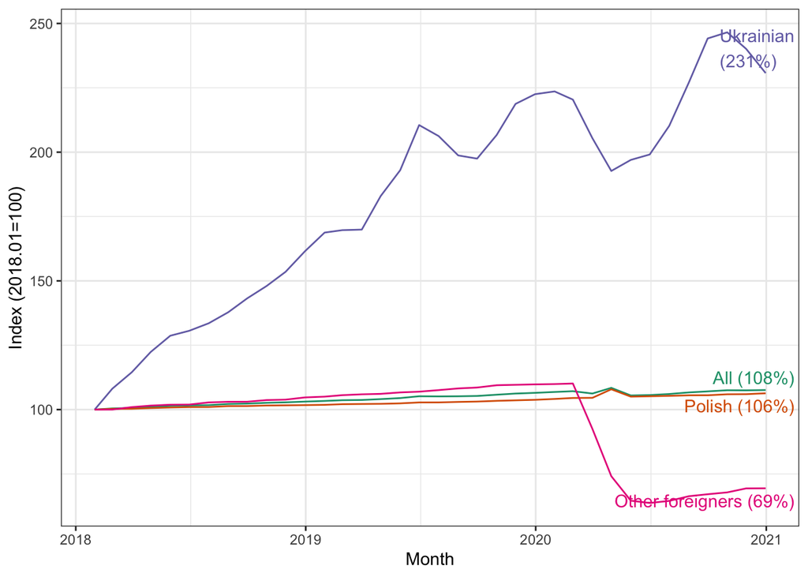

```r
selectivv_ind |>
  mutate(group = factor(group, c("total", "polish", "ukrainian", "other"),
                        c("All", "Polish", "Ukrainian", "Other foreigners")),
         label = if_else(month == max(month), paste0(as.character(group), " (", round(index), "%)"),  NA_character_),
         label = ifelse(group == "Ukrainian" & month == max(month),
                        paste0(as.character(group), "\n(", round(index), "%)"), label)) |>
  ggplot(data = _, aes(x = month, y = index, group = group, color = group)) +
  geom_line(show.legend = FALSE) +
  scale_colour_brewer(type = "qual", palette = "Dark2", name = "Users")  +
  geom_text_repel(aes(label = label),
                  nudge_x = -0.25,
                  direction = "y",
                  hjust = "bottom",
                  box.padding = .2,
                  force = 1,
                  na.rm = TRUE,
                  show.legend = FALSE) +
  labs(x = "Month", y = "Index (2018.01=100)") -> p_cov

p_cov
```

```r
ggsave(plot = p_cov, file = "figures//fig-sel-index-total.png", width = 7, height = 4)
```

Figure 2 – A~comparison of changes in the number of users according to Selectivv and the number of insured foreigners according to ZUS (2019.01 = 100). Note: ZUS (M) – monthly statistics; ZUS (Q) – quarterly statistics

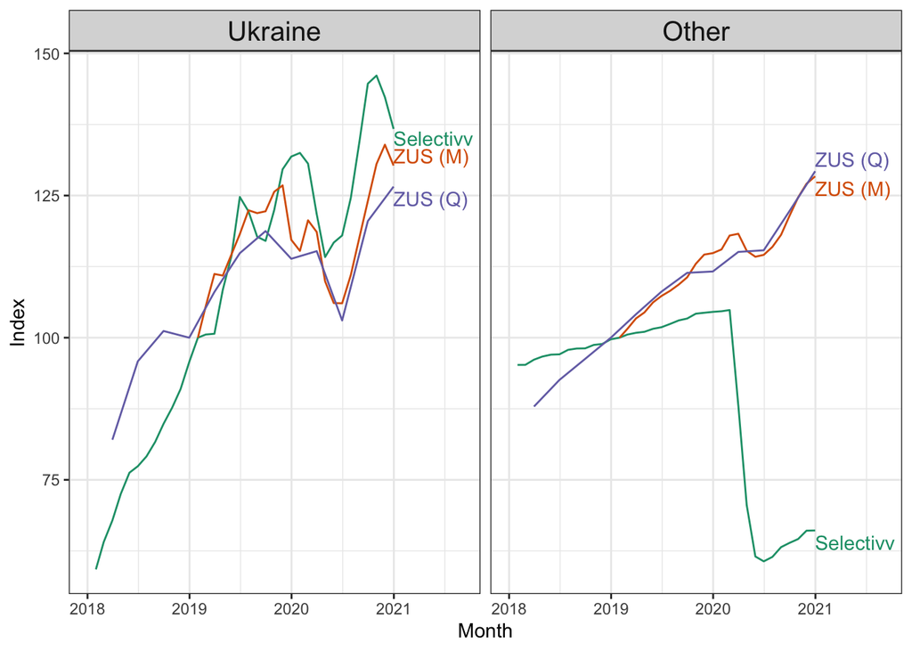

```r
selectivv_ind_with_zus  |>
  mutate(group = factor(group, c("ukrainian", "other"), c("Ukraine", "Other")),
         source = factor(source, c("selectivv", "zus", "zus (kw)"), c("Selectivv", "ZUS (M)", "ZUS (Q)")),
         label = if_else(month == max(month), as.character(source), NA_character_)) |>
  ggplot(data = _, aes(x = month, y = index_new, color = source, group = source)) +
  geom_line(show.legend = FALSE) +
  geom_text_repel(aes(label = label),
                  nudge_x = -0.25,
                  direction = "y",
                  hjust = "left",
                  box.padding = .1,
                  force = .8,
                  na.rm = TRUE,
                  show.legend = FALSE) +
  facet_wrap(~group)  +
  theme_bw() +
  scale_color_brewer(type = "qual", palette = "Dark2") +
  labs(x = "Month", y = "Index", linetype = "Source") +
  scale_x_date(limits = c(as.Date("2018-01-01"), as.Date("2021-09-01"))) +
  theme(strip.text = element_text(size = 15)) -> p1

p1
```

```r
ggsave(plot = p1, file = "figures/fig-sel-zus.png", width = 7, height = 4)
```

## 3.2 Section ‘Assessment of the measurement error’

Figure 3 – Comparison of gender and age of Polish citizens according to the Population Register (PESEL) and Selectivv

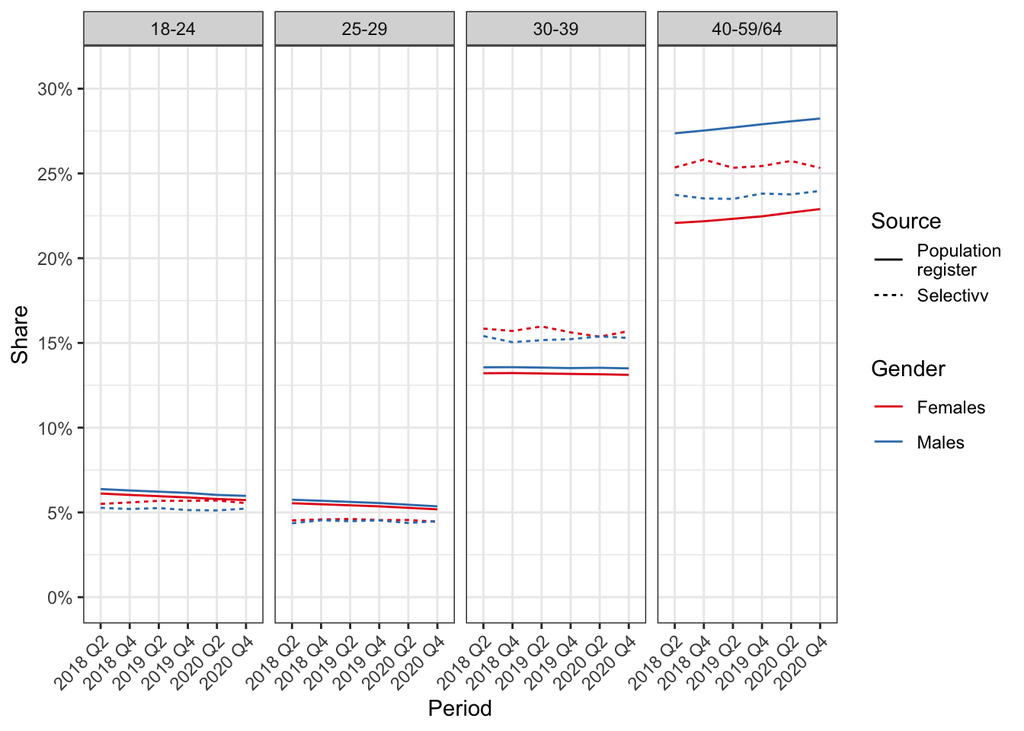

```r
valid_pesel_polish |>
  add_count(period, wt = pesel, name = "total") |>
  mutate(p_pesel = pesel / total) |>
  select(-pesel, -total) |>
  left_join(
    valid_sel_polish
  ) |>
  rename(pesel=p_pesel, selectivv=p_sel) |>
  pivot_longer(cols = pesel:selectivv, names_to = "source", values_to = "share") |>
  mutate(gender = factor(gender, c("Females", "Males")),
         source = factor(source, c("pesel", "selectivv"), c("Population\nregister", "Selectivv"))) |>
  ggplot(aes(x = period, y = share,
             linetype = source,
             group = interaction(source, gender),
             color = gender)) +
  geom_line() +
  #geom_point() +
  facet_wrap(~age, ncol = 4) +
  scale_y_continuous(limits = c(0, .31), labels = scales::percent, n.breaks = 10) +
  scale_color_brewer(type = "qual", palette = "Set1") +
  labs(x = "Period", y = "Share", linetype = "Source", color = "Gender") +
  theme(axis.text.x = element_text(angle = 45, vjust = 1, hjust = 1)) -> p3

p3
```

```r
ggsave(plot = p3, filename = "figures/comp-polish-gender-age.png", width = 6, height = 4)
```

Figure 4 – Comparison of gender and age of Ukrainian citizens according to the Population Register (PESEL), Social Insurance Register (ZUS) and Selectivv

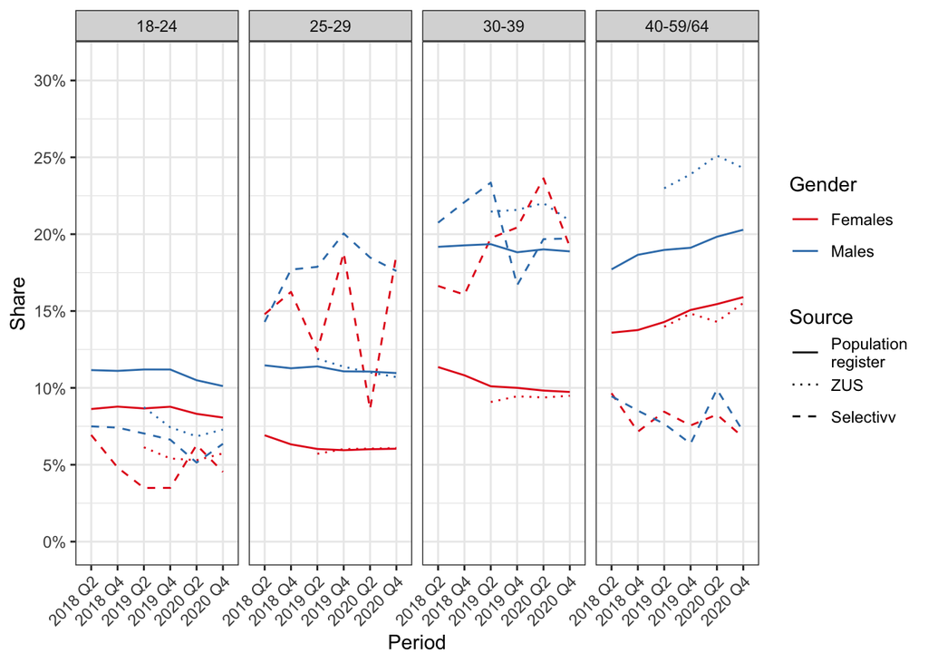

```r
valid_pesel_ukr |>
  add_count(period, wt = pesel, name = "total") |>
  mutate(p_pesel = pesel / total) |>
  select(-pesel, -total) |>
  left_join(
    valid_sel_ukr
  ) |>
  left_join(
    valid_zus_ukr |>
      add_count(period, wt = zus, name = "total") |>
      mutate(p_zus = zus/total) |>
      select(-zus, -total)
  ) |>
  rename(pesel=p_pesel, selectivv=p_sel, zus=p_zus) |>
  pivot_longer(cols = pesel:zus, names_to = "source", values_to = "share") |>
  mutate(gender = factor(gender, c("Females", "Males")),
         source = factor(source, c("pesel", "zus", "selectivv"),
                         c("Population\nregister", "ZUS", "Selectivv"))) |>
  ggplot(aes(x = period, y = share,
             linetype = source,
             group = interaction(source, gender),
             color = gender)) +
  geom_line() +
  #geom_point() +
  facet_wrap(~age, ncol = 4) +
  scale_y_continuous(limits = c(0, .31), labels = scales::percent, n.breaks = 10) +
  scale_linetype_manual(values = c(1,3,2)) +
  scale_color_brewer(type = "qual", palette = "Set1") +
  labs(x = "Period", y = "Share", linetype = "Source", color = "Gender") +
  theme(axis.text.x = element_text(angle = 45, vjust = 1, hjust = 1)) -> p4

p4
```

```r
ggsave(plot = p4, filename = "figures/comp-ukr-gender-age.png", width = 6, height = 4)
```

Tables:

- Classification table for nationality

```r
valid_survey |>
  mutate(country_stated = case_when(q1_a == 1 ~ "Poland",
                                    q1_b == 1 ~ "Ukraine",
                                    q1_c == 1 ~ "Belarus"),
         country_class = case_when(country_PL == 1 ~ "Poland",
                                   country_UA == 1 ~ "Ukraine",
                                   country_BY == 1 ~ "Belarus"),
         country_stated = factor(country_stated, c("Poland", "Ukraine", "Belarus")),
         country_class = factor(country_class, c("Poland", "Ukraine", "Belarus"))) |>
  xtabs(formula=~country_class + country_stated)
```

```
             country_stated
country_class Poland Ukraine Belarus
      Poland     494       0       0
      Ukraine      2     281       2
      Belarus      3       3     201
```

- Classification table for gender

```r
valid_survey |>
  mutate(gender_stated = case_when(q2_a == 1 ~ "Female",
                                    q2_b == 1 ~ "Male"),
         gender_class = case_when(gender_women == 1 ~ "Female",
                                   gender_men == 1 ~ "Male")) |>
  xtabs(formula=~gender_class + gender_stated)
```

```
            gender_stated
gender_class Female Male
      Female    491    3
      Male        3  489
```

- Classification table for age groups

```r
valid_survey |>
  mutate(age_stated = case_when(q3_a == 1 ~ "18-24",
                                q3_b == 1 ~ "25-29",
                                q3_c == 1 ~ "30-39",
                                q3_d == 1 ~ "40+"),
         age_class = case_when(age_18_24 == 1 ~ "18-24",
                               age_25_29 == 1 ~ "25-29",
                               age_30_39 == 1 ~ "30-39",
                               age_40 == 1 ~ "40+")) |>
  xtabs(formula=~age_class + age_stated)
```

```
         age_stated
age_class 18-24 25-29 30-39 40+
    18-24   339     1     0   0
    25-29     5   310     0   0
    30-39     1     7   159   0
    40+       0     1     1 162
```

## 3.3 Section ‘Characteristics of Polish gig workers’

Figure – The monthly number of active users in Poland for selected apps by category between 2018 and 2020

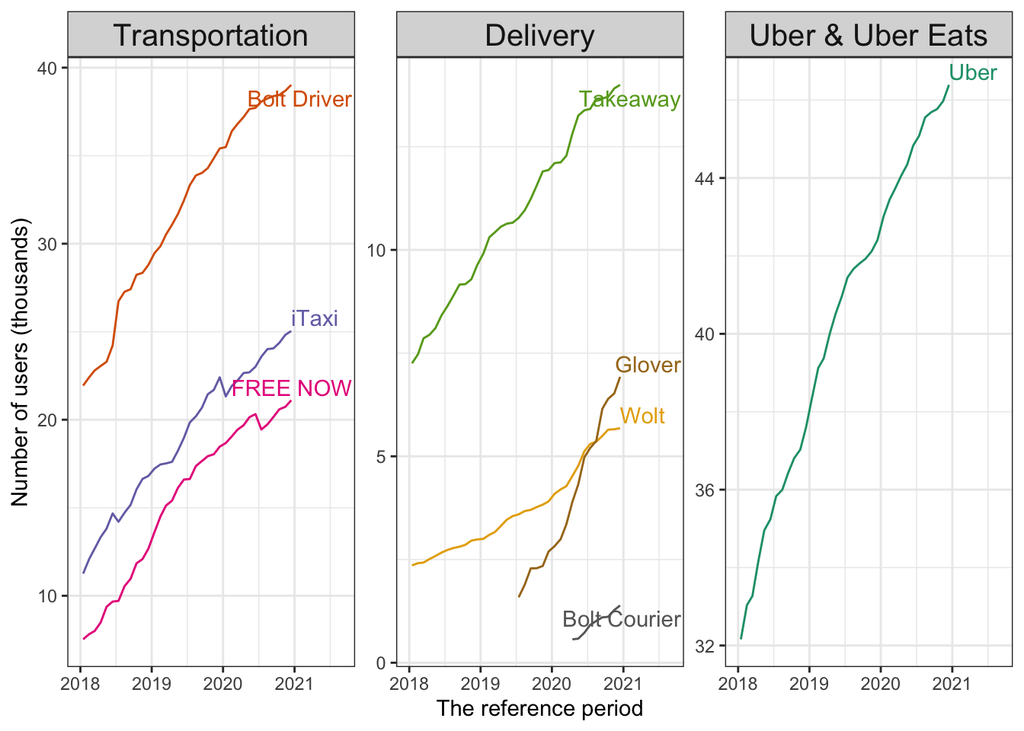

```r
selectivv[[1]] |>
  mutate(label = if_else(month == max(month), as.character(apps), NA_character_),
         category = ifelse(apps == "Uber", "Uber & Uber Eats", category),
         apps = factor(apps, c("Uber", "Bolt Driver", "iTaxi", "FREE NOW",
                               "Takeaway", "Wolt", "Glover",  "Bolt Courier")),
         category = factor(category, c("Transportation", "Delivery", "Uber & Uber Eats"))) |>
  ggplot(data = _, aes(x = month, y = number_of_users/1000, color = apps, group = apps)) +
  geom_line(show.legend = FALSE) +
  geom_text_repel(aes(label = label),
                  nudge_x = -0.25,
                  direction = "y",
                  hjust = "left",
                  box.padding = .1,
                  force = .8,
                  na.rm = TRUE,
                  show.legend = FALSE) +
  scale_color_brewer(type = "qual", palette = "Dark2") +
  labs(x = "The reference period", y = 'Number of users (thousands)', color = "App") +
  facet_wrap(~category, scales = "free_y") +
  scale_x_date(limits = c(as.Date("2018-01-01"), as.Date("2021-09-01"))) +
  theme(strip.text = element_text(size = 15)) ->  p2

p2
```

```r
ggsave(plot = p2, file = "figures/fig-sel-month.png", width = 6, height = 4)
```

Figure – Change in the number of active users in Poland for selected apps by type between 2018 and 2020. Base 2018HY1

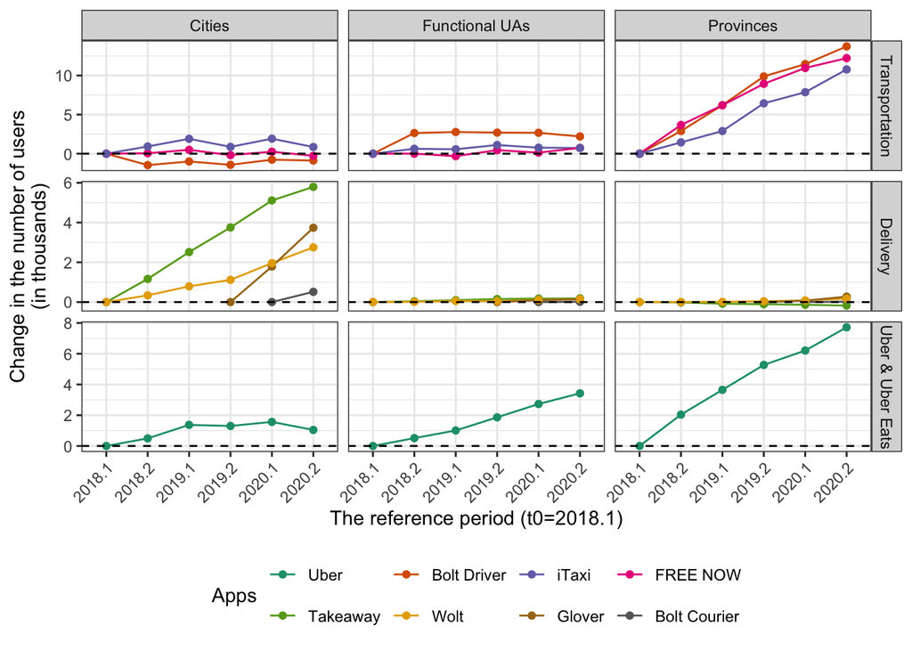

```r
selectivv[[3]] |>
  count(category, apps, group, period, wt = number_of_users) |>
  spread(group, n) |>
  mutate(fua = `Functional area` - Cities,
         woj = Voivodeship - `Functional area`) |>
  select(category, apps, period, cities = Cities, fua, woj) |>
  gather(geo, val, -apps, -period, -category) |>
  mutate(geo = factor(geo, c("cities", "fua", "woj"),
                      c("Cities", "Functional UAs", "Provinces")),
         category = ifelse(apps == "Uber", "Uber & Uber Eats", category),
         category  = factor(category, c("Transportation", "Delivery", "Uber & Uber Eats"))) |>
  group_by(apps, geo) |>
  mutate(index = val/val[1],
         diff = val-val[1],
         apps = factor(apps, c("Uber", "Bolt Driver", "iTaxi", "FREE NOW",
                               "Takeaway", "Wolt", "Glover",  "Bolt Courier"))) |>
  ggplot(data = _, aes(x = as.factor(period), y = diff/1000, group = apps, color = apps)) +
  geom_line() +
  geom_point() +
  scale_color_brewer(type = "qual", palette = "Dark2") +
  facet_grid(category ~ geo, scales = "free_y") +
  geom_hline(yintercept = 0, linetype = "dashed") +
  labs(x = "The reference period (t0=2018.1)",
       y = "Change in the number of users\n(in thousands)", color = "Apps") +
  theme(axis.text.x = element_text(angle = 45, vjust = 1, hjust = 1),
        legend.position = "bottom",
        legend.direction = "horizontal") +
  guides(color = guide_legend(nrow = 2, byrow = TRUE)) ->  p1b

p1b
```

```r
ggsave(plot = p1b, file = "figures/fig-sel-diff-hy.png", width = 8, height = 5)
```

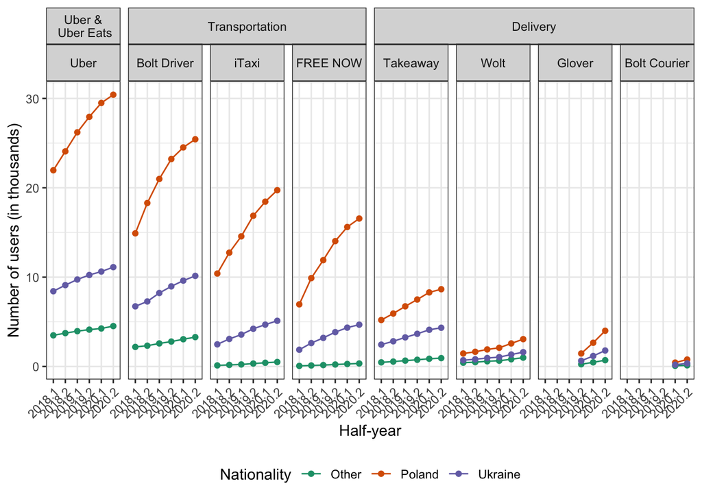

```r
selectivv[[2]] |>
  mutate(apps = factor(apps, c("Uber", "Bolt Driver", "iTaxi", "FREE NOW",
                               "Takeaway", "Wolt", "Glover",  "Bolt Courier")),
         category = ifelse(apps == "Uber", "Uber &\n Uber Eats", category),
         category  = factor(category, c("Uber &\n Uber Eats", "Transportation", "Delivery"))) |>
  count(category, apps, country, period, wt = n_unique_users) |>
  ggplot(data = _, aes(x = as.character(period), y = n/1000, group = country, color = country)) +
  geom_line() +
  geom_point() +
  scale_color_brewer(type = "qual", palette = "Dark2") +
  facet_nested(~category + apps) +
  labs(x = "Half-year", y = "Number of users (in thousands)", color = "Nationality") +
  theme(axis.text.x = element_text(angle = 45, vjust = 1, hjust = 1),
        legend.position = "bottom") -> p2a

p2a
```

```r
ggsave(plot = p2a, file = "figures/fig-sel-half-country.png", width = 8, height = 4)
```

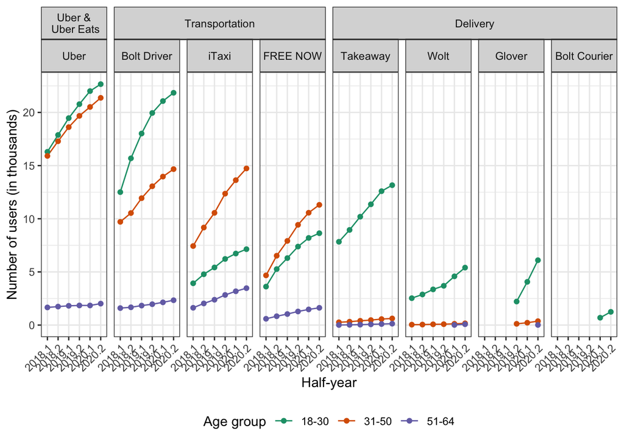

```r
selectivv[[2]]  |>
  mutate(apps = factor(apps, c("Uber", "Bolt Driver", "iTaxi", "FREE NOW",
                               "Takeaway", "Wolt", "Glover",  "Bolt Courier")),
         category = ifelse(apps == "Uber", "Uber &\n Uber Eats", category),
         category  = factor(category, c("Uber &\n Uber Eats", "Transportation", "Delivery"))) |>
  count(category, apps, age, period, wt = n_unique_users) |>
  ggplot(data = _, aes(x = as.character(period), y = n/1000, group = age, color = age)) +
  geom_line() +
  geom_point() +
  scale_color_brewer(type = "qual", palette = "Dark2") +
  facet_nested(~category + apps) +
  labs(x = "Half-year", y = "Number of users (in thousands)", color = "Age group") +
  theme(axis.text.x = element_text(angle = 45, vjust = 1, hjust = 1),
        legend.position = "bottom") -> p2b

p2b
```

```r
ggsave(plot = p2b, file = "figures/fig-sel-half-age.png", width = 8, height = 4)
```

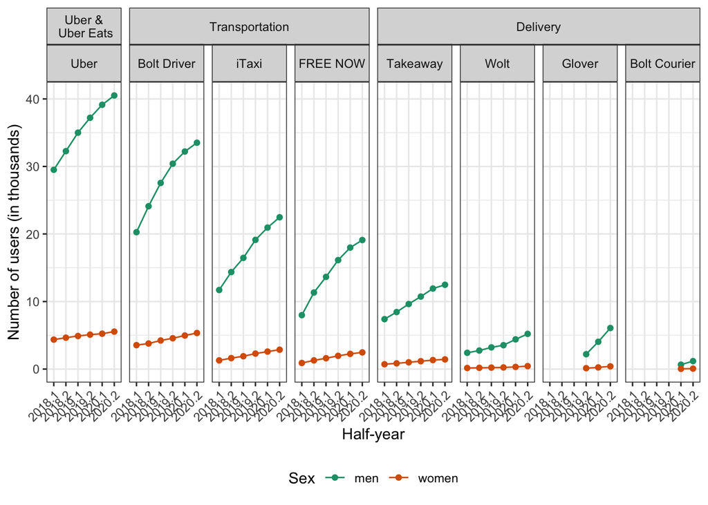

```r
selectivv[[2]]  |>
  mutate(apps = factor(apps, c("Uber", "Bolt Driver", "iTaxi", "FREE NOW",
                               "Takeaway", "Wolt", "Glover",  "Bolt Courier")),
         category = ifelse(apps == "Uber", "Uber &\n Uber Eats", category),
         category  = factor(category, c("Uber &\n Uber Eats", "Transportation", "Delivery"))) |>
  count(category, apps, gender, period, wt = n_unique_users)  |>
  ggplot(data = _, aes(x = as.character(period), y = n/1000, group = gender, color = gender)) +
  geom_line() +
  geom_point() +
  scale_color_brewer(type = "qual", palette = "Dark2") +
  facet_nested(~category + apps) +
  labs(x = "Half-year", y = "Number of users (in thousands)", color = "Sex") +
  theme(axis.text.x = element_text(angle = 45, vjust = 1, hjust = 1),
        legend.position = "bottom") -> p2c

p2c
```

```r
ggsave(plot = p2c, file = "figures/fig-sel-half-sex.png", width = 8, height = 4)
```

Figure – Point and 95% interval of ratio of the number of active users and the LFS working 18–65 population by app for 2020HY1. Note that Y axis differs between the apps

```r
selectivv[[3]]  |>
    filter(group == "Cities")  |>
    mutate(period = as.character(period)) |>
    select(category, period, region_name, apps, number_of_users) |>
    left_join(
      bael |>
        mutate(region_name = str_remove(region_name, "M. "))
    ) |>
    filter(number_of_users > 0 ) -> cities_bael
```

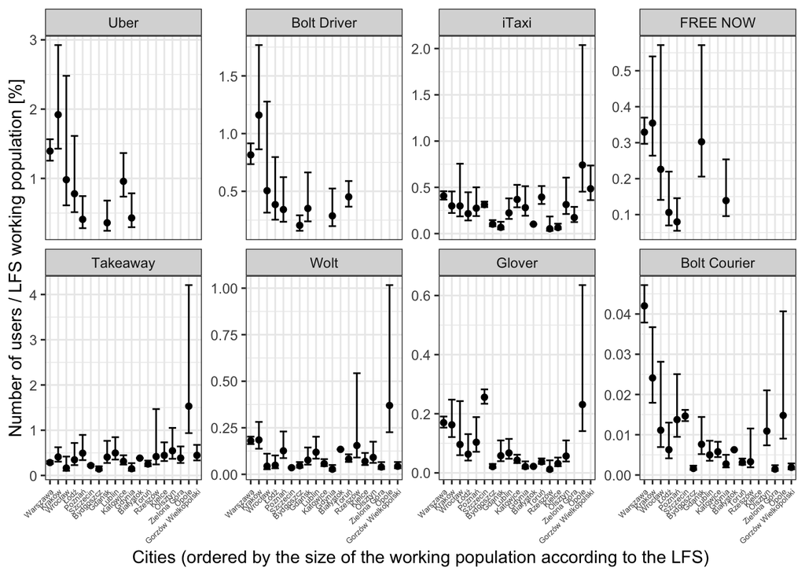

```r
cities_bael |>
  filter(region_name != "Sopot", period == "2020.1") |>
  filter(!is.na(y))  |>
  mutate(share = number_of_users/y*100,
         share_hi = number_of_users / (y - 1.96*rmse)*100,
         share_lo = number_of_users / (y + 1.96*rmse)*100) |>
  mutate(apps = factor(apps, c("Uber", "Bolt Driver", "iTaxi", "FREE NOW",
                               "Takeaway", "Wolt", "Glover",  "Bolt Courier"))) |>
  ggplot(data = _, aes(x = reorder(region_name, -y), y = share, ymin = share_lo, ymax = share_hi)) +
  geom_errorbar() +
  geom_point()  +
  facet_wrap(~apps, ncol = 4, scale = "free_y") +
  theme(axis.text.x = element_text(angle = 45, vjust = 1, hjust = 1, size = 5))  +
  #scale_y_continuous(labels = scales::label_percent(accuracy = 2)) +
  labs(x = "Cities (ordered by the size of the working population according to the LFS)",
       y = "Number of users / LFS working population [%]") -> p3

p3
```

```r
ggsave(plot = p3, file = "figures/fig-sel-cities-shares.png", width = 8, height = 4)
```

Figure – Average and standard deviation (Std. Dev.) of activity time by app type, app, weekdays and hours

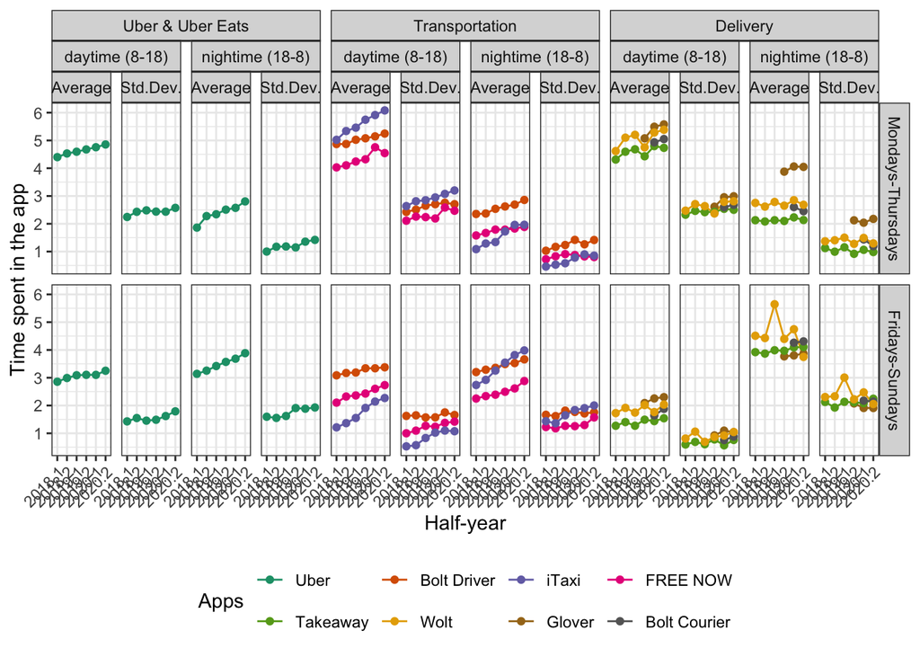

```r
selectivv[[4]] |>
  mutate(category = ifelse(apps == "Uber", "Uber & Uber Eats", category),
         category  = factor(category, c( "Uber & Uber Eats", "Transportation", "Delivery")),
         apps = factor(apps, c("Uber", "Bolt Driver", "iTaxi", "FREE NOW",
                               "Takeaway", "Wolt", "Glover",  "Bolt Courier")),
         day = factor(day, c("Mondays-Thursdays", "Fridays-Sundays")),
         hour = str_replace(hour, "day", "daytime"),
         hour = str_replace(hour, "night", "nightime"))  |>
  ggplot(data = _, aes(x = as.character(period), y = activity_time, color = apps, group = apps)) +
  geom_line() +
  geom_point() +
  facet_nested(day ~ category +  hour + statistic)  +
  scale_color_brewer(type = "qual", palette = "Dark2", name = "Apps") +
  theme(axis.text.x=element_text(angle = 45, vjust = 1, hjust = 1),
        legend.position = "bottom") +
  labs(x = "Half-year", y = "Time spent in the app") +
  scale_y_continuous(breaks = seq(0,7,1)) +
  guides(color = guide_legend(nrow = 2, byrow = TRUE))  -> p4

p4
```

```r
ggsave(plot = p4, file = "figures/fig-sel-half-time-dev.png", width = 8, height = 5)
```

# 4 Supplementary materials

Table Number of active users in cities for 2020HY2

```r
selectivv[[3]] |>
    filter(group == "Cities") |>
    mutate(apps = factor(apps, c("Uber", "Bolt Driver", "iTaxi", "FREE NOW",
                                 "Takeaway", "Wolt", "Glover",  "Bolt Courier"))) |>
    filter(number_of_users > 0, period == "2020.2")  |>
    select(period, apps, region_name, number_of_users) |>
    spread(apps, number_of_users) |>
    select(-period) |>
    xtable(digits = 0) |>
    print.xtable(include.rownames = F, NA.string = "--")
```

```
% latex table generated in R 4.2.2 by xtable 1.8-4 package
% Mon May  1 17:13:35 2023
\begin{table}[ht]
\centering
\begin{tabular}{lrrrrrrrr}
  \hline
region\_name & Uber & Bolt Driver & iTaxi & FREE NOW & Takeaway & Wolt & Glover & Bolt Courier \\
  \hline
Białystok & -- & -- & 96 & -- & 630 & 205 & 56 & 24 \\
  Bydgoszcz & -- & 274 & 178 & -- & 297 & 101 & 71 & 12 \\
  Gdańsk & 472 & 542 & 104 & 450 & 778 & 156 & 170 & 32 \\
  Gdynia & 479 & 401 & 373 & 120 & 245 & 48 & 53 & 10 \\
  Gorzów Wielkopolski & -- & -- & 178 & -- & 311 & 27 & 15 & 5 \\
  Katowice & 1578 & -- & 482 & -- & 558 & 106 & 121 & 21 \\
  Kielce & -- & -- & 12 & -- & 442 & 75 & 65 & 18 \\
  Kraków & 6808 & 4166 & 994 & 1219 & 1619 & 792 & 893 & 170 \\
  Łódź & 1762 & 793 & 405 & 230 & 908 & 140 & 261 & 33 \\
  Lublin & -- & -- & 344 & -- & 958 & 226 & 187 & 18 \\
  Olsztyn & -- & -- & 190 & -- & 533 & 90 & 122 & 20 \\
  Opole & -- & -- & 310 & -- & 912 & 238 & 204 & 30 \\
  Poznań & 835 & 701 & 506 & 64 & 1288 & 350 & 410 & 62 \\
  Rzeszów & -- & -- & 41 & -- & 459 & 169 & 36 & 22 \\
  Sopot & 80 & 249 & 179 & 35 & 196 & 38 & 42 & 8 \\
  Szczecin & -- & -- & 461 & -- & 387 & 52 & 254 & 55 \\
  Toruń & -- & 336 & 370 & -- & 276 & 94 & 66 & 11 \\
  Warszawa & 12637 & 7799 & 3692 & 2954 & 1878 & 1956 & 2358 & 533 \\
  Wrocław & 3217 & 1617 & 931 & 620 & 540 & 165 & 505 & 78 \\
  Zielona Góra & -- & -- & 178 & -- & 348 & 32 & 17 & 6 \\
   \hline
\end{tabular}
\end{table}
```

Table – Direct estimates, its standard errors (in thousands) and sample sizes of the working population size (18–64) based on the Labour Force Survey between 2018HY1 and 2020HY

```r
bael |>
  filter(period == "2018.1")  |>
  mutate(region_name = str_remove(region_name, "M. "),
         y = y / 1000,
         rmse = rmse / 1000,
         cv = rmse/y*100) |>
  select(region_name, size = y, std = rmse, sample = n) |>
  left_join(
    bael |>
    filter(period == "2018.2")  |>
    mutate(region_name = str_remove(region_name, "M. "),
         y = y / 1000,
         rmse = rmse / 1000,
         cv = rmse/y*100) |>
    select(region_name, size = y, std = rmse, sample = n),
    by = "region_name"
  ) |>
  left_join(
    bael |>
    filter(period == "2019.1")  |>
    mutate(region_name = str_remove(region_name, "M. "),
         y = y / 1000,
         rmse = rmse / 1000,
         cv = rmse/y*100) |>
    select(region_name, size = y, std = rmse, sample = n),
    by = "region_name"
  )  |>
  left_join(
    bael |>
    filter(period == "2019.2")  |>
    mutate(region_name = str_remove(region_name, "M. "),
         y = y / 1000,
         rmse = rmse / 1000,
         cv = rmse/y*100) |>
    select(region_name, size = y, std = rmse, sample = n),
    by = "region_name"
  )  |>
  left_join(
    bael |>
    filter(period == "2020.1")  |>
    mutate(region_name = str_remove(region_name, "M. "),
         y = y / 1000,
         rmse = rmse / 1000,
         cv = rmse/y*100) |>
    select(region_name, size = y, std = rmse, sample = n),
    by = "region_name"
  )  |>
  mutate_at(vars(starts_with("sample")), as.integer) |>
  xtable(digits = 1) |>
  print.xtable(include.rownames = F)
```

```
% latex table generated in R 4.2.2 by xtable 1.8-4 package
% Mon May  1 17:13:36 2023
\begin{table}[ht]
\centering
\begin{tabular}{lrrrrrrrrrrrrrrr}
  \hline
region\_name & size.x & std.x & sample.x & size.y & std.y & sample.y & size.x.x & std.x.x & sample.x.x & size.y.y & std.y.y & sample.y.y & size & std & sample \\
  \hline
Białystok & 132.2 & 2.9 & 988 & 132.4 & 11.5 & 934 & 128.2 & 0.6 & 892 & 138.9 & 1.6 & 879 & 127.4 & 0.1 & 845 \\
  Bydgoszcz & 175.9 & 20.2 & 1359 & 170.4 & 24.0 & 1250 & 165.5 & 13.4 & 1179 & 163.3 & 20.2 & 1046 & 183.6 & 27.9 & 1052 \\
  Gdańsk & 180.5 & 33.0 & 847 & 190.5 & 42.3 & 842 & 207.0 & 16.4 & 852 & 206.6 & 36.4 & 807 & 170.3 & 40.9 & 660 \\
  Gdynia & 142.7 & 3.9 & 363 & 145.1 & 14.4 & 351 & 134.8 & 8.1 & 326 & 132.4 & 6.9 & 292 & 145.3 & 33.5 & 319 \\
  Gorzów Wielkopolski & 67.0 & 9.8 & 1002 & 59.0 & 13.8 & 809 & 63.4 & 5.9 & 848 & 53.9 & 11.7 & 722 & 52.8 & 9.2 & 713 \\
  Katowice & 139.1 & 29.5 & 819 & 142.3 & 20.4 & 725 & 150.3 & 16.9 & 705 & 167.4 & 37.0 & 690 & 155.5 & 23.7 & 661 \\
  Kielce & 84.7 & 16.5 & 869 & 88.9 & 22.6 & 870 & 86.4 & 19.0 & 884 & 86.8 & 29.6 & 867 & 89.0 & 17.9 & 807 \\
  Kraków & 408.0 & 15.3 & 904 & 418.3 & 20.3 & 793 & 415.6 & 63.3 & 776 & 430.5 & 53.5 & 756 & 360.8 & 63.2 & 640 \\
  Lublin & 176.0 & 20.7 & 1371 & 167.6 & 19.2 & 1195 & 162.8 & 26.5 & 1156 & 153.0 & 30.4 & 1033 & 160.0 & 33.7 & 1022 \\
  Olsztyn & 79.5 & 18.7 & 959 & 83.3 & 27.2 & 967 & 76.4 & 25.9 & 891 & 83.6 & 22.9 & 878 & 82.5 & 20.2 & 953 \\
  Opole & 55.5 & 16.5 & 786 & 59.8 & 11.8 & 800 & 60.1 & 16.3 & 841 & 56.4 & 15.5 & 782 & 54.1 & 17.6 & 870 \\
  Poznań & 268.5 & 41.9 & 893 & 269.0 & 64.9 & 841 & 259.0 & 28.7 & 774 & 278.1 & 65.1 & 719 & 232.6 & 53.5 & 785 \\
  Rzeszów & 101.8 & 22.9 & 1050 & 105.3 & 31.8 & 1022 & 107.5 & 30.7 & 1095 & 104.7 & 27.0 & 991 & 91.1 & 33.2 & 1052 \\
  Sopot & 6.0 & 17.4 & 16 & 4.2 & 23.8 & 10 & 7.0 & 12.8 & 17 & 3.4 & 10.4 &  8 & 3.5 & 10.7 &  8 \\
  Szczecin & 200.5 & 37.1 & 1147 & 196.2 & 20.5 & 1055 & 205.0 & 14.0 & 951 & 189.3 & 25.8 & 759 & 191.1 & 9.2 & 671 \\
  Toruń & 91.5 & 12.8 & 1176 & 98.8 & 10.0 & 1211 & 92.3 & 14.7 & 1055 & 95.2 & 14.4 & 1039 & 95.8 & 11.4 & 916 \\
  Warszawa & 968.2 & 26.8 & 1827 & 978.5 & 63.5 & 1677 & 899.7 & 28.9 & 1660 & 944.8 & 19.4 & 1445 & 909.2 & 50.7 & 1454 \\
  Wrocław & 320.9 & 61.2 & 858 & 350.5 & 49.1 & 1006 & 343.2 & 67.8 & 977 & 342.2 & 92.4 & 833 & 314.6 & 97.0 & 805 \\
  Zielona Góra & 63.9 & 11.0 & 856 & 65.9 & 10.9 & 810 & 65.2 & 16.0 & 784 & 65.9 & 12.3 & 790 & 68.5 & 13.9 & 811 \\
  Łódź & 328.5 & 16.1 & 637 & 334.3 & 16.9 & 510 & 291.5 & 1.8 & 489 & 298.3 & 18.2 & 448 & 238.7 & 63.0 & 442 \\
   \hline
\end{tabular}
\end{table}
```